# Video Game Data

Ramses Monjaras

2025-05-04

Video games are very popular, that thousands of them get released throughout the years on different platforms. I started to wonder which platforms have the best games and active player base. You can find this data set in the [Kaggle](https://www.kaggle.com/datasets/zafarali27/game-data) website. In the data set the game ID, name, genre, release year and platform are all categorical variables. The global sales, user rating, and active players are all quantitative variables and they are also all ordinal. This data set seems to be cleaned from the start, so I didn’t touch anything. Below is what my data set look like.

```r
  df[1:10,]
```

```
##    Game_ID      Game_Name     Genre    Platform Release_Year Global_Sales
## 1    G0001 Warrior Galaxy Adventure      Switch         2002        28.62
## 2    G0002   Legend Quest    Action      Mobile         2019        24.17
## 3    G0003  Empire Battle Adventure PlayStation         2016        37.46
## 4    G0004    Shadow Rise  Strategy PlayStation         2019        17.05
## 5    G0005    Quest Arena Adventure      Switch         2020        31.26
## 6    G0006    Empire Fury    Action      Switch         2008        39.62
## 7    G0007   Quest Legend  Strategy      Mobile         2019        11.35
## 8    G0008     Rise Quest    Action PlayStation         2024        16.86
## 9    G0009   Warrior Rise   Shooter        Xbox         2008        42.30
## 10   G0010     Rise Arena   Shooter PlayStation         2023        46.94
##    User_Rating Active_Players
## 1          4.8           95.7
## 2          5.4           50.9
## 3          9.6           50.5
## 4          8.9           82.2
## 5          1.3           41.8
## 6          2.2           97.7
## 7          8.3           95.1
## 8          6.8           53.4
## 9          2.6           60.5
## 10         7.1           22.3
```

# Part 1

For one of my quantitative variable, I am going to take the user rating to give the summary statistics. Below is the five point summary which is min = 1.0, Q1 = 3.3, med = 5.5, Q3 = 7.6, and max = 10. The mean is 5.476 and the standard deviation is 2.562662. Below is also a histogram of the user score.

```r
summary(df$User_Rating)
```

```
##    Min. 1st Qu.  Median    Mean 3rd Qu.    Max.
##   1.000   3.300   5.500   5.476   7.600  10.000
```

```r
sd(df$User_Rating)
```

```
## [1] 2.562662
```

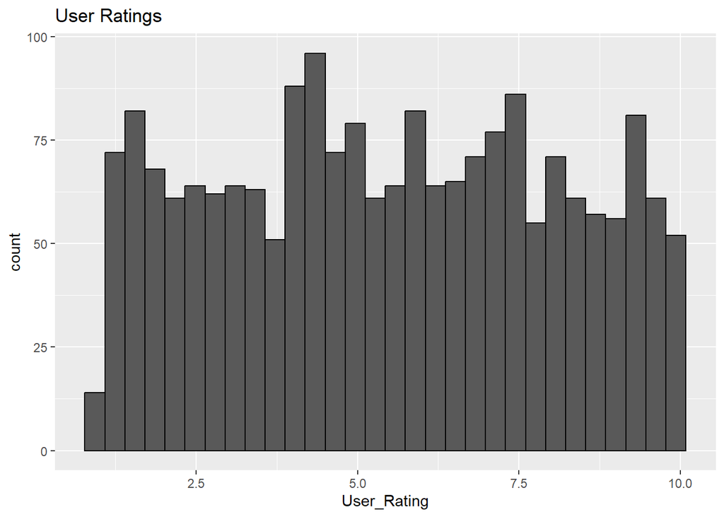

```r
ggplot(df, aes(x = User_Rating)) + geom_histogram() + labs(title = "User Ratings") + geom_histogram(color = 'black')
```

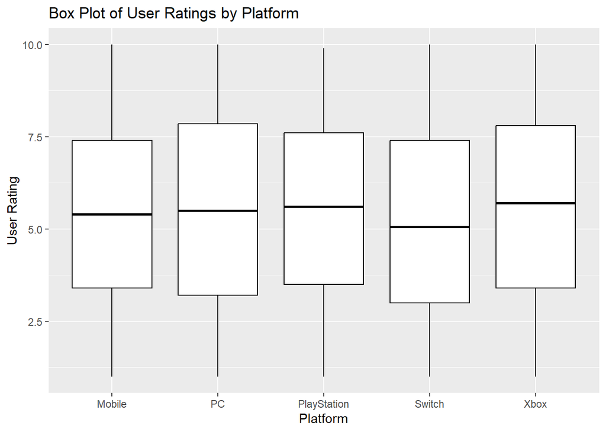

```r
ggplot(data = df, aes(x = Platform, y = User_Rating)) + geom_boxplot(color = 'black') + labs(title = "Box Plot of User Ratings by Platform", x = "Platform", y = "User Rating")
```

```r
five_point_summary <- df |>
  group_by(Platform) |>
  summarise(
    Min = min(User_Rating, na.rm = TRUE),
    Q1 = quantile(User_Rating, 0.25, na.rm = TRUE),
    Median = median(User_Rating, na.rm = TRUE),
    Q3 = quantile(User_Rating, 0.75, na.rm = TRUE),
    Max = max(User_Rating, na.rm = TRUE),
    Mean = mean(User_Rating, na.rm = TRUE)
  )

print(five_point_summary)
```

```
## # A tibble: 5 × 7
##   Platform      Min    Q1 Median    Q3   Max  Mean
##   <chr>       <dbl> <dbl>  <dbl> <dbl> <dbl> <dbl>
## 1 Mobile          1   3.4   5.4   7.4   10    5.46
## 2 PC              1   3.2   5.5   7.85  10    5.54
## 3 PlayStation     1   3.5   5.6   7.6    9.9  5.51
## 4 Switch          1   3     5.05  7.4   10    5.28
## 5 Xbox            1   3.4   5.7   7.8   10    5.60
```

As you can see in the box plot above, the x-axis is the different platforms and the y-axis is the user ratings. It looks like there are no outliers in the box plots. What I find interesting is the switch games having a lower user rating on average compared to the other platforms. This side-by-side plot also shows how many high rated games are on each platform. It looks like Xbox games has a higher user rating compared to the other platforms. Next, I will take a categorical variable to create a frequency and a relative frequency table. Below is the frequency table and relative frequency.

```r
df |> count(Genre) |>
  mutate(relative_frequency = n / sum(n))
```

```
##       Genre   n relative_frequency
## 1    Action 304             0.1520
## 2 Adventure 283             0.1415
## 3       RPG 270             0.1350
## 4    Racing 320             0.1600
## 5   Shooter 244             0.1220
## 6    Sports 269             0.1345
## 7  Strategy 310             0.1550
```

The total count of the genre is 2,000 and the total count of the relative frequency is 1. What I found interesting is that there are more racing games compared to all the different genres.

```r
two_way_table <- df |>
  count(Platform, Genre) |>
  pivot_wider(names_from = Genre, values_from = n, values_fill = list(n = 0))
print(two_way_table)
```

```
## # A tibble: 5 × 8
##   Platform    Action Adventure   RPG Racing Shooter Sports Strategy
##   <chr>        <int>     <int> <int>  <int>   <int>  <int>    <int>
## 1 Mobile          59        53    48     62      63     49       68
## 2 PC              59        57    59     72      41     57       58
## 3 PlayStation     61        55    48     65      49     49       62
## 4 Switch          66        55    57     62      48     56       68
## 5 Xbox            59        63    58     59      43     58       54
```

In the two-way table above, the table shows the different amount of genres that each platform has. I find interesting that there is a lot of Pc racing games but less amount of shooter games in the PC platform. The possible relationship of these two variables is that, if you are interested in a specific genre of games, then you can look at this table and see which platform has the most of that genre.

# Part 2

```r
model <- lm(Active_Players ~ User_Rating, data = df)
summary(model)
```

```
##
## Call:
## lm(formula = Active_Players ~ User_Rating, data = df)
##
## Residuals:
##     Min      1Q  Median      3Q     Max
## -51.868 -24.807   0.465  24.494  51.405
##
## Coefficients:
##             Estimate Std. Error t value Pr(>|t|)
## (Intercept)  52.9246     1.4981  35.327   <2e-16 ***
## User_Rating  -0.4566     0.2478  -1.843   0.0655 .
## ---
## Signif. codes:  0 '***' 0.001 '**' 0.01 '*' 0.05 '.' 0.1 ' ' 1
##
## Residual standard error: 28.39 on 1998 degrees of freedom
## Multiple R-squared:  0.001697,   Adjusted R-squared:  0.001197
## F-statistic: 3.396 on 1 and 1998 DF,  p-value: 0.06552
```

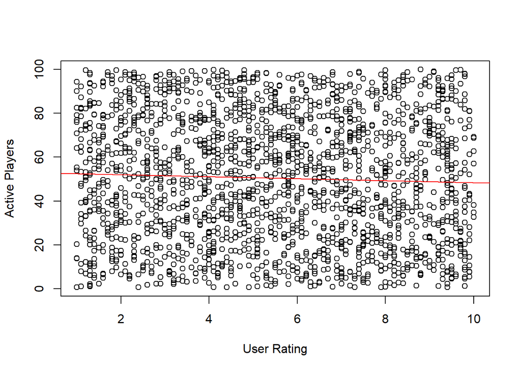

```r
plot(df$User_Rating, df$Active_Players, xlab="User Rating", ylab="Active Players" )

abline(model, col="red")
```

As you can see this simple y ~ x regression is very all over the place and the regression line seems to be in a straight line. This tells me that if a game has a high rating, that doesn’t mean people will keep playing the game. I also include statistics above that shows the five point summary of the regression. Below will be the multiple regression.

```r
model <- lm(Active_Players ~ User_Rating + Global_Sales + Release_Year, data = df)

summary(model)
```

```
##
## Call:
## lm(formula = Active_Players ~ User_Rating + Global_Sales + Release_Year,
##     data = df)
##
## Residuals:
##     Min      1Q  Median      3Q     Max
## -52.905 -24.776   0.249  24.351  50.998
##
## Coefficients:
##                Estimate Std. Error t value Pr(>|t|)
## (Intercept)  -212.23174  173.31445  -1.225   0.2209
## User_Rating    -0.46977    0.24792  -1.895   0.0583 .
## Global_Sales    0.01512    0.04376   0.346   0.7297
## Release_Year    0.13162    0.08614   1.528   0.1266
## ---
## Signif. codes:  0 '***' 0.001 '**' 0.01 '*' 0.05 '.' 0.1 ' ' 1
##
## Residual standard error: 28.39 on 1996 degrees of freedom
## Multiple R-squared:  0.002911,   Adjusted R-squared:  0.001412
## F-statistic: 1.942 on 3 and 1996 DF,  p-value: 0.1207
```

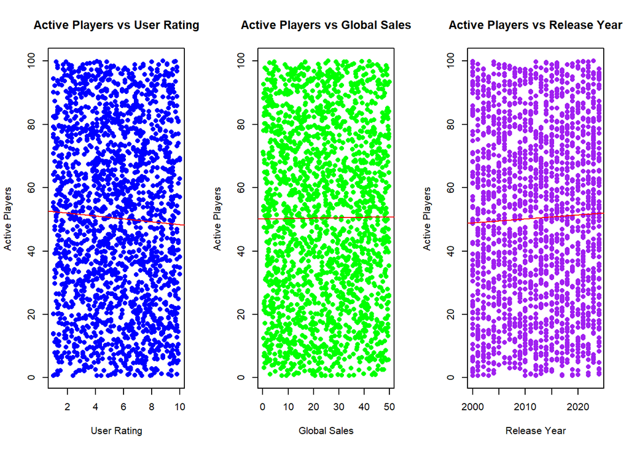

```r
par(mfrow = c(1, 3))
plot(df$User_Rating, df$Active_Players, main = "Active Players vs User Rating", xlab = "User Rating", ylab = "Active Players", pch = 16, col = "blue")
abline(lm(Active_Players ~ User_Rating, data = df), col = "red")

plot(df$Global_Sales, df$Active_Players, main = "Active Players vs Global Sales", xlab = "Global Sales", ylab = "Active Players", pch = 16, col = "green")
abline(lm(Active_Players~ Global_Sales, data = df), col = "red")

plot(df$Release_Year, df$Active_Players, main = "Active Players vs Release Year", xlab = "Release Year", ylab = "Active Players", pch = 16, col = "purple")
abline(lm(Active_Players~ Release_Year, data = df), col = "red")
```

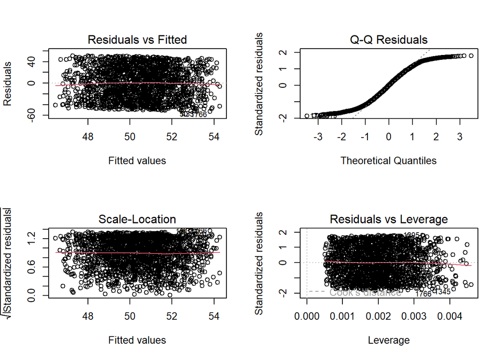

```r
par(mfrow = c(2, 2))
plot(model)
```

```r
coefficients <- coef(model)
print(coefficients)
```

```
##   (Intercept)   User_Rating  Global_Sales  Release_Year
## -212.23174033   -0.46977423    0.01512277    0.13162348
```

```r
r_squared <- summary(model)$r.squared
adj_r_squared <- summary(model)$adj.r.squared
print(paste("R-squared:", r_squared))
```

```
## [1] "R-squared: 0.00291098002038272"
```

```r
print(paste("Adjusted R-squared:", adj_r_squared))
```

```
## [1] "Adjusted R-squared: 0.00141234922883016"
```

```r
p_values <- summary(model)$coefficients[, 4]
print(p_values)
```

```
##  (Intercept)  User_Rating Global_Sales Release_Year
##    0.2208904    0.0582557    0.7296920    0.1266491
```

As you can see above, the multiple regression is still noisy. In the Active Player vs. User Rating, the regression line seems to be negative, Active Players vs. Global Sales seems to be positive, and Active Players vs. Release Year is also positive. What I find interesting is how Active Players seems to go down when a game has a higher user rating. I also added a statistic to show the five point summary of the multiple regression.

```r
model <- lm(User_Rating ~ Active_Players + Global_Sales + Active_Players:Global_Sales, data = df)

summary(model)
```

```
##
## Call:
## lm(formula = User_Rating ~ Active_Players + Global_Sales + Active_Players:Global_Sales,
##     data = df)
##
## Residuals:
##     Min      1Q  Median      3Q     Max
## -4.6762 -2.1416 -0.0056  2.1250  4.6359
##
## Coefficients:
##                               Estimate Std. Error t value Pr(>|t|)
## (Intercept)                  5.8336050  0.2254656  25.874   <2e-16 ***
## Active_Players              -0.0072092  0.0039142  -1.842   0.0656 .
## Global_Sales                -0.0071233  0.0080362  -0.886   0.3755
## Active_Players:Global_Sales  0.0001458  0.0001400   1.041   0.2979
## ---
## Signif. codes:  0 '***' 0.001 '**' 0.01 '*' 0.05 '.' 0.1 ' ' 1
##
## Residual standard error: 2.562 on 1996 degrees of freedom
## Multiple R-squared:  0.00224,    Adjusted R-squared:  0.0007399
## F-statistic: 1.493 on 3 and 1996 DF,  p-value: 0.2144
```

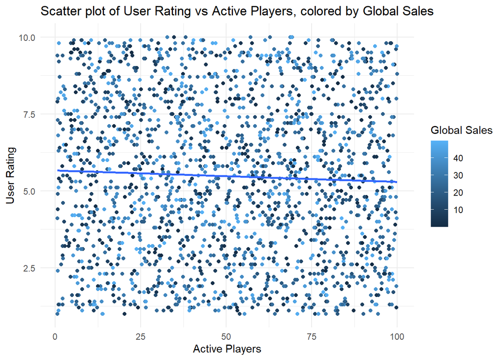

```r
ggplot(df, aes(x = Active_Players, y = User_Rating, color = Global_Sales)) +
  geom_point() +
  geom_smooth(method = "lm", se = FALSE) +
  labs(title = "Scatter plot of User Rating vs Active Players, colored by Global Sales",
       x = "Active Players", y = "User Rating", color = "Global Sales") +
  theme_minimal()
```

[figure not shown]

```r
interaction.plot(df$Active_Players, df$Global_Sales, df$User_Rating,
                 xlab = "Active Players", ylab = "User Rating", trace.label = "Global Sales",
                 main = "Interaction Plot of Active Players and Global Sales on User Rating")
```

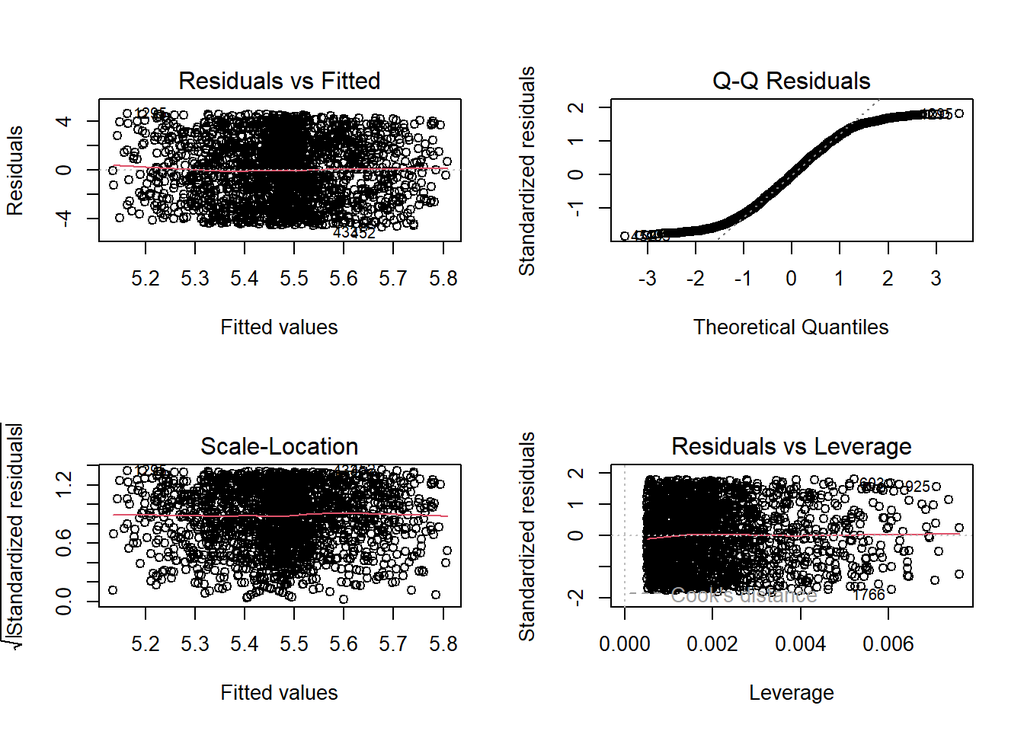

```r
par(mfrow = c(2, 2))
plot(model)
```

```r
coefficients <- coef(model)
print(coefficients)
```

```
##                 (Intercept)              Active_Players
##                5.8336050350               -0.0072092218
##                Global_Sales Active_Players:Global_Sales
##               -0.0071232686                0.0001457598
```

```r
r_squared <- summary(model)$r.squared
adj_r_squared <- summary(model)$adj.r.squared
print(paste("R-squared:", r_squared))
```

```
## [1] "R-squared: 0.00223952463394565"
```

```r
print(paste("Adjusted R-squared:", adj_r_squared))
```

```
## [1] "Adjusted R-squared: 0.00073988464091046"
```

```r
p_values <- summary(model)$coefficients[, 4]
print(p_values)
```

```
##                 (Intercept)              Active_Players
##               1.561718e-127                6.564836e-02
##                Global_Sales Active_Players:Global_Sales
##                3.755108e-01                2.978670e-01
```

```r
model <- nls(Global_Sales ~ a * exp(b * User_Rating), data = df, start = list(a = 1, b = 0.1))

summary(model)
```

```
##
## Formula: Global_Sales ~ a * exp(b * User_Rating)
##
## Parameters:
##    Estimate Std. Error t value Pr(>|t|)
## a 2.448e+01  7.656e-01  31.969   <2e-16 ***
## b 1.521e-04  5.172e-03   0.029    0.977
## ---
## Signif. codes:  0 '***' 0.001 '**' 0.01 '*' 0.05 '.' 0.1 ' ' 1
##
## Residual standard error: 14.52 on 1998 degrees of freedom
##
## Number of iterations to convergence: 7
## Achieved convergence tolerance: 3.844e-07
```

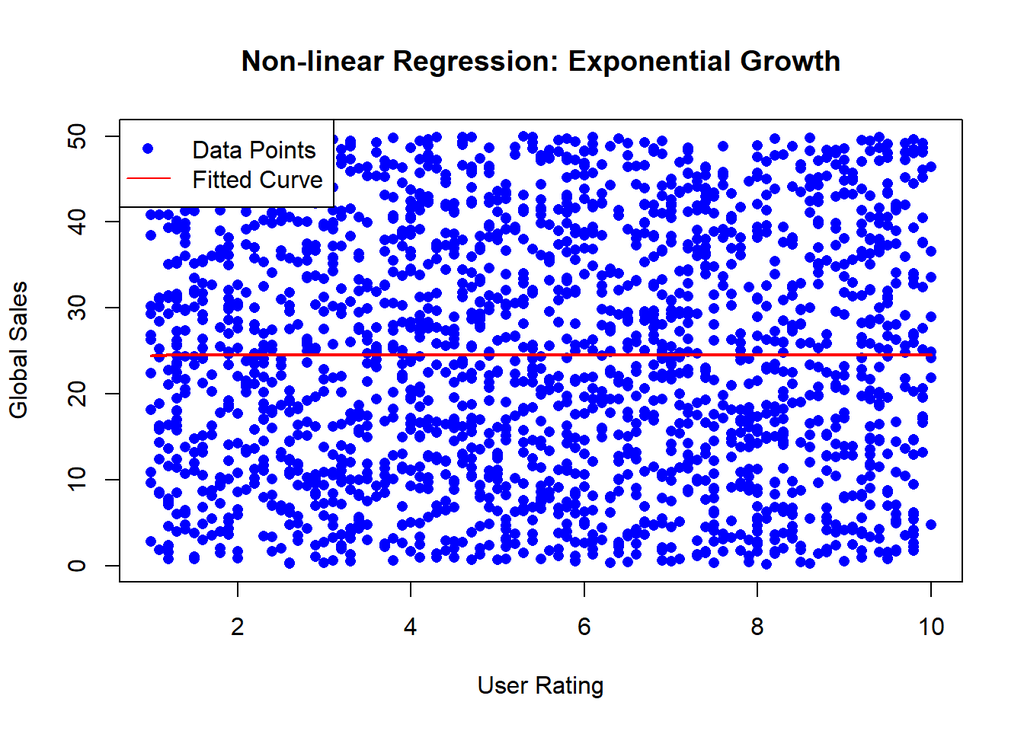

```r
plot(df$User_Rating, df$Global_Sales, main = "Non-linear Regression: Exponential Growth",
     xlab = "User Rating", ylab = "Global Sales", pch = 16, col = "blue")

predict_fun <- function(x) {
  predict(model, newdata = data.frame(User_Rating = x))
}

curve(predict_fun(x), add = TRUE, col = "red", lwd = 2)

legend("topleft", legend = c("Data Points", "Fitted Curve"),
       col = c("blue", "red"), pch = c(16, NA), lty = c(NA, 1))
```

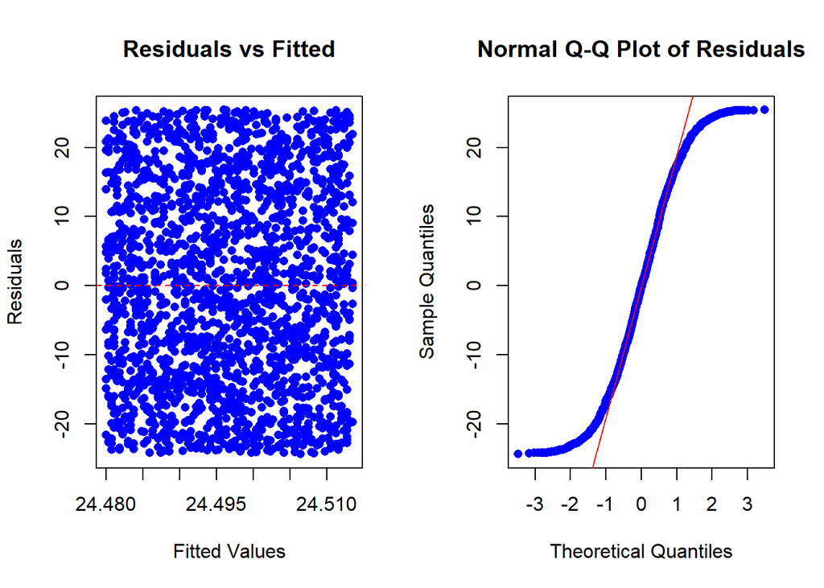

```r
fitted_values <- predict(model)
residuals <- residuals(model)

par(mfrow = c(1, 2))
plot(fitted_values, residuals, main = "Residuals vs Fitted",
     xlab = "Fitted Values", ylab = "Residuals", pch = 16, col = "blue")
abline(h = 0, col = "red", lty = 2)

qqnorm(residuals, main = "Normal Q-Q Plot of Residuals", pch = 16, col = "blue")
qqline(residuals, col = "red")
```

```r
parameters <- coef(model)
print(parameters)
```

```
##            a            b
## 2.447625e+01 1.521459e-04
```

```r
resid_se <- summary(model)$sigma
print(paste("Residual Standard Error:", resid_se))
```

```
## [1] "Residual Standard Error: 14.5176345887746"
```

```r
conf_int <- confint(model)
print(conf_int)
```

```
##          2.5%      97.5%
## a 22.99439939 26.0069743
## b -0.01003401  0.0103382
```

Above is the non-linear regression. It looks like there is not much of a growth happening on both the exponential growth and the residuals vs fitted graphs. The Q-Q plot has a increasing regression line which I found interesting.

#Part 3

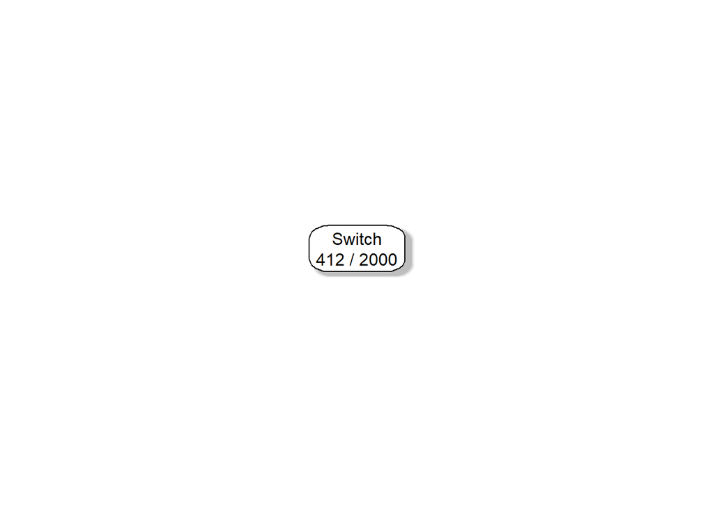

```r
tree <- rpart(Platform ~ Active_Players + User_Rating, data = df, control = rpart.control(minslpit = 2, minbucket = 1, cp = 0.01))
tree <- rpart(Platform ~., data =df[, c("Platform", "User_Rating", "Active_Players")])


rpart.plot(tree, extra = 2,
           type = 4,
           fallen.leaves = TRUE,
           box.palette="white",
           branch.lty = 3,
           shadow.col = "gray")
```

```r
pred <- predict(tree, type = "class")
head(pred)
```

```
##      1      2      3      4      5      6
## Switch Switch Switch Switch Switch Switch
## Levels: Mobile PC PlayStation Switch Xbox
```

```r
predict(tree) |> head()
```

```
##   Mobile     PC PlayStation Switch  Xbox
## 1  0.201 0.2015      0.1945  0.206 0.197
## 2  0.201 0.2015      0.1945  0.206 0.197
## 3  0.201 0.2015      0.1945  0.206 0.197
## 4  0.201 0.2015      0.1945  0.206 0.197
## 5  0.201 0.2015      0.1945  0.206 0.197
## 6  0.201 0.2015      0.1945  0.206 0.197
```

```r
confusionMatrix(table(predicted =pred, actual = df$Platform))
```

```
## Confusion Matrix and Statistics
##
##              actual
## predicted     Mobile  PC PlayStation Switch Xbox
##   Mobile           0   0           0      0    0
##   PC               0   0           0      0    0
##   PlayStation      0   0           0      0    0
##   Switch         402 403         389    412  394
##   Xbox             0   0           0      0    0
##
## Overall Statistics
##
##                Accuracy : 0.206
##                  95% CI : (0.1885, 0.2244)
##     No Information Rate : 0.206
##     P-Value [Acc > NIR] : 0.5089
##
##                   Kappa : 0
##
##  Mcnemar's Test P-Value : NA
##
## Statistics by Class:
##
##                      Class: Mobile Class: PC Class: PlayStation Class: Switch
## Sensitivity                  0.000    0.0000             0.0000         1.000
## Specificity                  1.000    1.0000             1.0000         0.000
## Pos Pred Value                 NaN       NaN                NaN         0.206
## Neg Pred Value               0.799    0.7985             0.8055           NaN
## Prevalence                   0.201    0.2015             0.1945         0.206
## Detection Rate               0.000    0.0000             0.0000         0.206
## Detection Prevalence         0.000    0.0000             0.0000         1.000
## Balanced Accuracy            0.500    0.5000             0.5000         0.500
##                      Class: Xbox
## Sensitivity                0.000
## Specificity                1.000
## Pos Pred Value               NaN
## Neg Pred Value             0.803
## Prevalence                 0.197
## Detection Rate             0.000
## Detection Prevalence       0.000
## Balanced Accuracy          0.500
```

```r
summary(tree)
```

```
## Call:
## rpart(formula = Platform ~ ., data = df[, c("Platform", "User_Rating",
##     "Active_Players")])
##   n= 2000
##
##            CP nsplit rel error xerror xstd
## 1 0.008186398      0         1      0    0
##
## Node number 1: 2000 observations
##   predicted class=Switch  expected loss=0.794  P(node) =1
##     class counts:   402   403   389   412   394
##    probabilities: 0.201 0.202 0.195 0.206 0.197
```

Above is the simple decision tree and I’m using the game platform as my categorical variable. I also have a confusion matrix that shows the prediction of the game platform. I believe that the active players is the most important variable.

```r
train_control <- trainControl(
  method = "cv",
  number = 10,
  savePredictions = TRUE,
  classProbs = TRUE,
  summaryFunction = multiClassSummary
)


set.seed(42)
tree_model_cv <- train(
  Platform ~ Active_Players + User_Rating,
  data = df,
  method = "rpart",
  trControl = train_control,
  tuneLength = 5,       # Try 5 different complexity parameters
  metric = "Accuracy"   # Optimization metric
)
print(tree_model_cv)
```

```
## CART
##
## 2000 samples
##    2 predictor
##    5 classes: 'Mobile', 'PC', 'PlayStation', 'Switch', 'Xbox'
##
## No pre-processing
## Resampling: Cross-Validated (10 fold)
## Summary of sample sizes: 1801, 1799, 1801, 1801, 1798, 1800, ...
## Resampling results across tuning parameters:
##
##   cp           logLoss   AUC        prAUC      Accuracy   Kappa
##   0.004093199  1.692298  0.4916528  0.1860204  0.1985210  -0.003010035
##   0.005037783  1.650275  0.4906744  0.1669795  0.1965258  -0.006787613
##   0.005667506  1.646238  0.4928888  0.1622173  0.1990534  -0.003655719
##   0.008186398  1.622452  0.4975162  0.1480485  0.1965408  -0.006674681
##   0.008816121  1.622449  0.4936989  0.1252066  0.1940357  -0.010673930
##   Mean_F1    Mean_Sensitivity  Mean_Specificity  Mean_Pos_Pred_Value
##   0.1963140  0.1972938         0.7994134         0.1940382
##   0.1755833  0.1942742         0.7986652         0.1894747
##   0.1778758  0.1967589         0.7992912         0.1987628
##         NaN  0.1943114         0.7986894               NaN
##         NaN  0.1912371         0.7978861               NaN
##   Mean_Neg_Pred_Value  Mean_Precision  Mean_Recall  Mean_Detection_Rate
##   0.7982889            0.1940382       0.1972938    0.03970420
##   0.7980856            0.1894747       0.1942742    0.03930516
##   0.7990455            0.1987628       0.1967589    0.03981068
##   0.7970135                  NaN       0.1943114    0.03930816
##   0.7959295                  NaN       0.1912371    0.03880714
##   Mean_Balanced_Accuracy
##   0.4983536
##   0.4964697
##   0.4980250
##   0.4965004
##   0.4945616
##
## Accuracy was used to select the optimal model using the largest value.
## The final value used for the model was cp = 0.005667506.
```

```r
cv_results <- tree_model_cv$results
print(cv_results)
```

```
##            cp  logLoss       AUC     prAUC  Accuracy        Kappa   Mean_F1
## 1 0.004093199 1.692298 0.4916528 0.1860204 0.1985210 -0.003010035 0.1963140
## 2 0.005037783 1.650275 0.4906744 0.1669795 0.1965258 -0.006787613 0.1755833
## 3 0.005667506 1.646238 0.4928888 0.1622173 0.1990534 -0.003655719 0.1778758
## 4 0.008186398 1.622452 0.4975162 0.1480485 0.1965408 -0.006674681       NaN
## 5 0.008816121 1.622449 0.4936989 0.1252066 0.1940357 -0.010673930       NaN
##   Mean_Sensitivity Mean_Specificity Mean_Pos_Pred_Value Mean_Neg_Pred_Value
## 1        0.1972938        0.7994134           0.1940382           0.7982889
## 2        0.1942742        0.7986652           0.1894747           0.7980856
## 3        0.1967589        0.7992912           0.1987628           0.7990455
## 4        0.1943114        0.7986894                 NaN           0.7970135
## 5        0.1912371        0.7978861                 NaN           0.7959295
##   Mean_Precision Mean_Recall Mean_Detection_Rate Mean_Balanced_Accuracy
## 1      0.1940382   0.1972938          0.03970420              0.4983536
## 2      0.1894747   0.1942742          0.03930516              0.4964697
```

[output cut: 27 more lines]

```r
print(paste("Optimal cp:", tree_model_cv$bestTune$cp))
```

```
## [1] "Optimal cp: 0.00566750629722922"
```

```r
cv_confusion <- confusionMatrix(tree_model_cv$pred$pred, tree_model_cv$pred$obs)
print(cv_confusion)
```

```
## Confusion Matrix and Statistics
##
##              Reference
## Prediction    Mobile  PC PlayStation Switch Xbox
##   Mobile         732 751         779    796  769
##   PC             361 310         323    309  394
##   PlayStation     78  99          68     73   63
##   Switch         582 569         539    651  536
##   Xbox           257 286         236    231  208
##
## Overall Statistics
##
##                Accuracy : 0.1969
##                  95% CI : (0.1891, 0.2048)
##     No Information Rate : 0.206
##     P-Value [Acc > NIR] : 0.9885
##
##                   Kappa : -0.0061
##
##  Mcnemar's Test P-Value : <2e-16
##
## Statistics by Class:
##
##                      Class: Mobile Class: PC Class: PlayStation Class: Switch
## Sensitivity                 0.3642    0.1538            0.03496        0.3160
## Specificity                 0.6126    0.8263            0.96114        0.7196
## Pos Pred Value              0.1913    0.1827            0.17848        0.2263
## Neg Pred Value              0.7930    0.7947            0.80487        0.8022
## Prevalence                  0.2010    0.2015            0.19450        0.2060
## Detection Rate              0.0732    0.0310            0.00680        0.0651
## Detection Prevalence        0.3827    0.1697            0.03810        0.2877
## Balanced Accuracy           0.4884    0.4901            0.49805        0.5178
##                      Class: Xbox
## Sensitivity               0.1056
## Specificity               0.8742
## Pos Pred Value            0.1708
## Neg Pred Value            0.7994
## Prevalence                0.1970
## Detection Rate            0.0208
## Detection Prevalence      0.1218
## Balanced Accuracy         0.4899
```

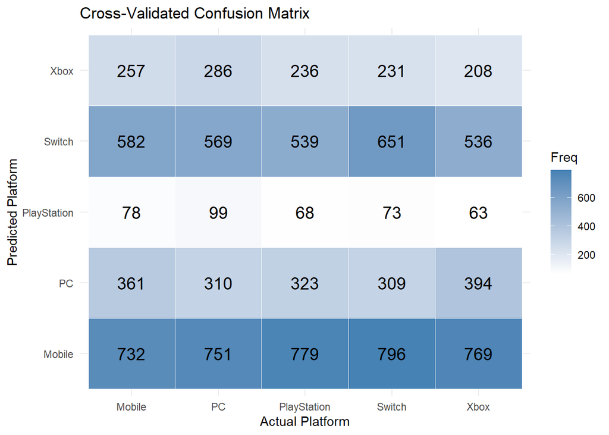

```r
ggplot(as.data.frame(cv_confusion$table),
       aes(x = Reference, y = Prediction, fill = Freq)) +
  geom_tile(color = "white") +
  geom_text(aes(label = Freq), color = "black", size = 5) +
  scale_fill_gradient(low = "white", high = "steelblue") +
  labs(title = "Cross-Validated Confusion Matrix",
       x = "Actual Platform",
       y = "Predicted Platform") +
  theme_minimal()
```

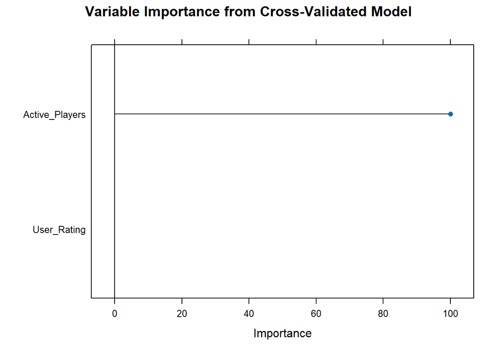

```r
var_imp <- varImp(tree_model_cv)
plot(var_imp, main = "Variable Importance from Cross-Validated Model")
```

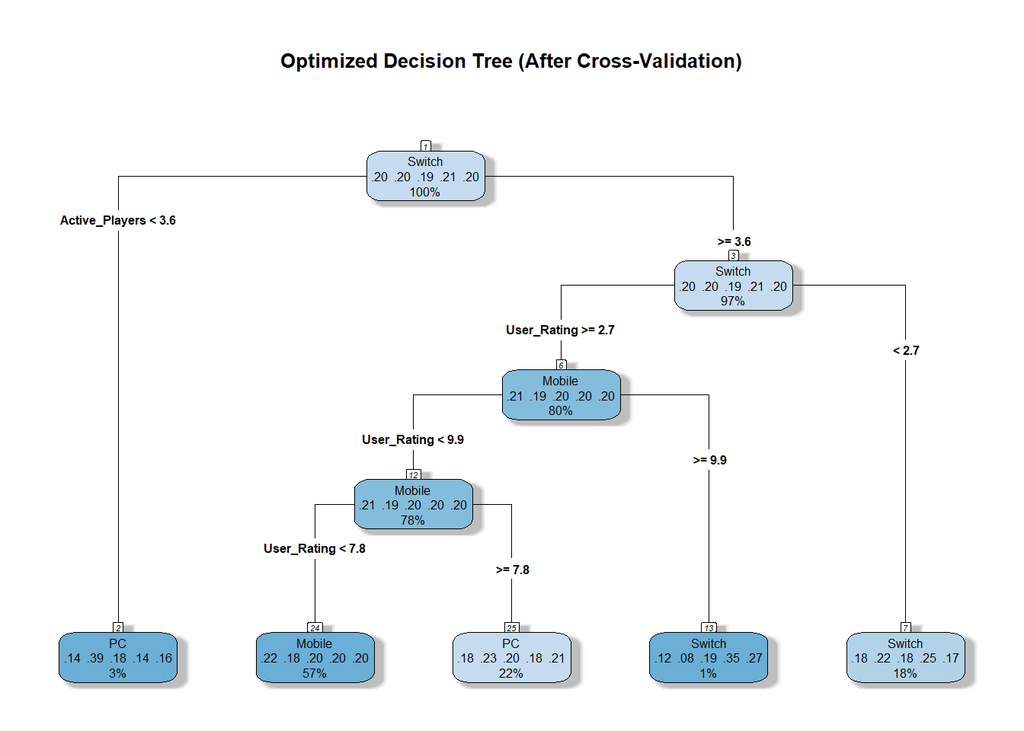

```r
rpart.plot(
  tree_model_cv$finalModel,
  type = 4,
  extra = 104,
  box.palette = "Blues",
  shadow.col = "gray",
  nn = TRUE,
  main = "Optimized Decision Tree (After Cross-Validation)"
)
```

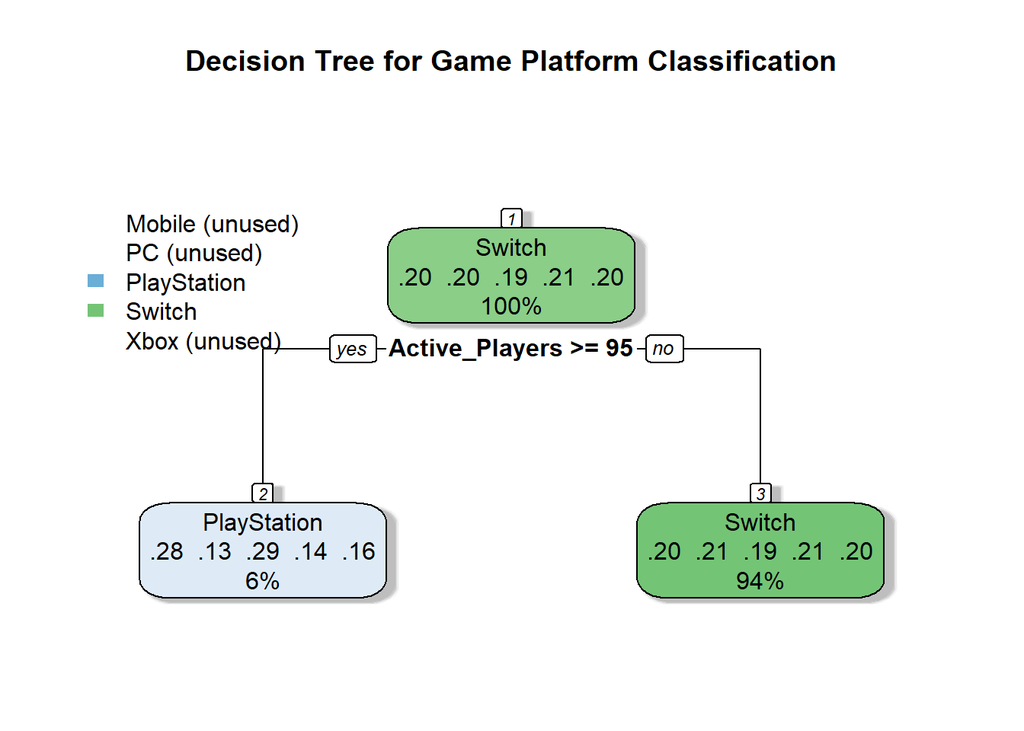

```r
set.seed(123)
train_index <- createDataPartition(df$Platform, p = 0.7, list = FALSE)
train_data <- df[train_index, ]
test_data <- df[-train_index, ]




tree_model <- rpart(Platform ~ Active_Players + User_Rating,
                    data = train_data,
                    method = "class")


rpart.plot(tree_model, main = "Decision Tree for Game Platform Classification",
           box.palette = "BuGn", shadow.col = "gray", nn = TRUE)
```

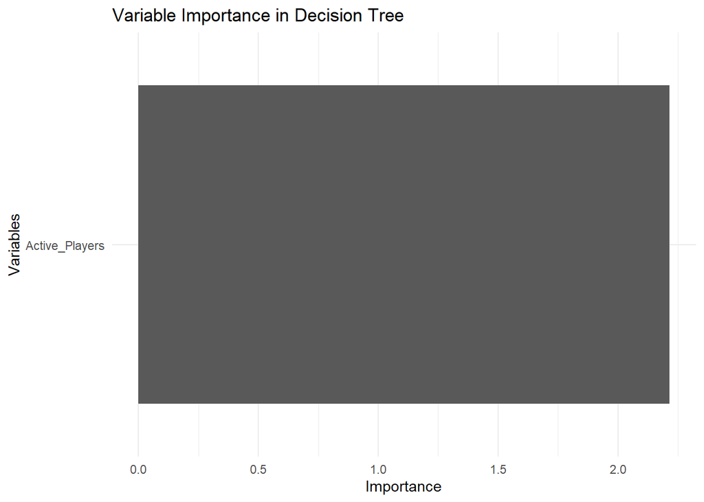

```r
tree_pred <- predict(tree_model, test_data, type = "class")





importance <- tree_model$variable.importance
importance_df <- data.frame(Variable = names(importance), Importance = importance)
importance_df <- importance_df[order(-importance_df$Importance), ]


ggplot(importance_df, aes(x = reorder(Variable, Importance), y = Importance)) +
  geom_bar(stat = "identity") +
  coord_flip() +
  labs(title = "Variable Importance in Decision Tree",
       x = "Variables",
       y = "Importance") +
  theme_minimal()
```

```r
cat("The most important variables for platform classification are:\n")
```

```
## The most important variables for platform classification are:
```

```r
print(head(importance_df, 3))
```

```
##                      Variable Importance
## Active_Players Active_Players   2.215122
```

```r
cat("\nFrom the variable importance analysis, we can see that",
    importance_df$Variable[1], "is the most significant predictor of game platform,",
    "followed by", importance_df$Variable[2], "and", importance_df$Variable[3],
    ". This suggests that these features have the strongest influence on determining",
    "which platform a game might belong to.")
```

[output not shown]

```r
train_data$Platform <- as.factor(train_data$Platform)
test_data$Platform <- as.factor(test_data$Platform)


svm_formula <- Platform ~ Active_Players + User_Rating
svm_train_x <- model.matrix(svm_formula, data = train_data)[,-1]
svm_train_y <- train_data$platform

svm_test_x <- model.matrix(svm_formula, data = test_data)[,-1]
svm_test_y <- test_data$platform


train_data$platform <- as.factor(train_data$Platform)
test_data$platform <- as.factor(test_data$Platform)



svm_train_x <- model.matrix(Platform ~ Active_Players + User_Rating,
                           data = train_data)

svm_test_x <- model.matrix(Platform ~ Active_Players + User_Rating,
                          data = test_data)


svm_train_y <- train_data$Platform
svm_test_y <- test_data$Platform


preProc <- preProcess(svm_train_x, method = c("center", "scale"))
svm_train_x_scaled <- predict(preProc, svm_train_x)
svm_test_x_scaled <- predict(preProc, svm_test_x)


svm_model <- svm(x = svm_train_x_scaled,
                 y = svm_train_y,
                 type = "C-classification",
                 kernel = "radial",
                 probability = TRUE,
                 scale = FALSE)

svm_pred <- predict(svm_model, svm_test_x_scaled)

conf_matrix <- confusionMatrix(svm_pred, svm_test_y)
print(conf_matrix)
```

```
## Confusion Matrix and Statistics
##
##              Reference
## Prediction    Mobile PC PlayStation Switch Xbox
##   Mobile          21 26          27     25   30
##   PC              16 13          20     13   14
##   PlayStation      9 11          10     14   17
##   Switch          43 44          33     47   39
##   Xbox            31 26          26     24   18
##
## Overall Statistics
##
##                Accuracy : 0.1826
##                  95% CI : (0.1524, 0.216)
##     No Information Rate : 0.206
##     P-Value [Acc > NIR] : 0.9305
##
##                   Kappa : -0.0235
##
##  Mcnemar's Test P-Value : 9.743e-08
##
## Statistics by Class:
##
##                      Class: Mobile Class: PC Class: PlayStation Class: Switch
## Sensitivity                0.17500   0.10833            0.08621       0.38211
## Specificity                0.77358   0.86792            0.89397       0.66456
## Pos Pred Value             0.16279   0.17105            0.16393       0.22816
## Neg Pred Value             0.78846   0.79463            0.80224       0.80563
## Prevalence                 0.20101   0.20101            0.19430       0.20603
## Detection Rate             0.03518   0.02178            0.01675       0.07873
## Detection Prevalence       0.21608   0.12730            0.10218       0.34506
## Balanced Accuracy          0.47429   0.48813            0.49009       0.52334
##                      Class: Xbox
## Sensitivity              0.15254
## Specificity              0.77662
## Pos Pred Value           0.14400
## Neg Pred Value           0.78814
## Prevalence               0.19765
## Detection Rate           0.03015
## Detection Prevalence     0.20938
## Balanced Accuracy        0.46458
```

#Part 4

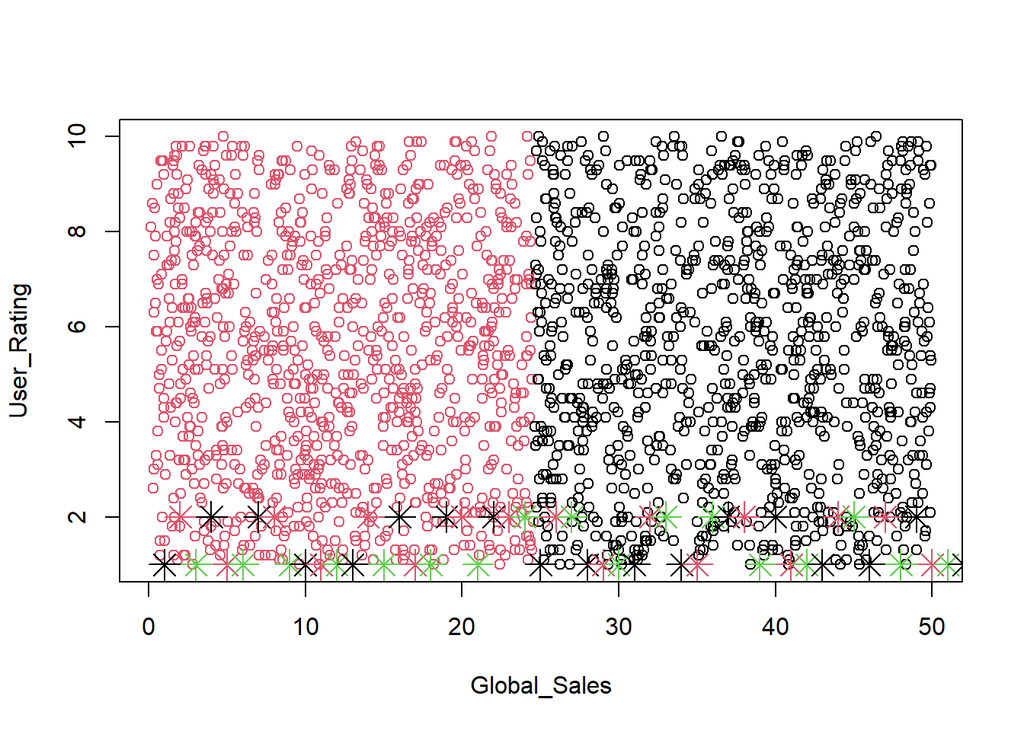

```r
cl <- kmeans(df[,c("Global_Sales", "User_Rating")],2)
plot(df[,c("Global_Sales","User_Rating")], col = cl$cluster)# pch =df$Platform)
points(cl$cluster, col = 1:3, pch = 8, cex = 2)
```

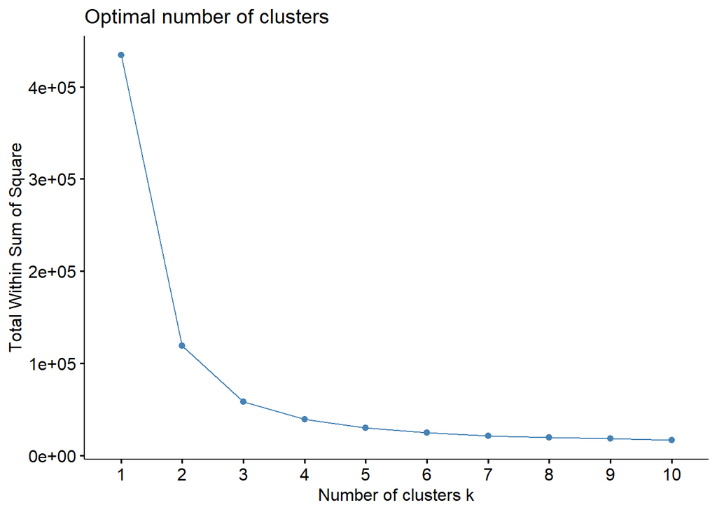

```r
fviz_nbclust(x = df[,c("Global_Sales","User_Rating")],FUNcluster = kmeans, method = 'wss' )
```

In part 4, I picked the game’s platform as my categorical variable. As you can see above, the table shows the k means clustering with 2 different clusters. As you can see above there is also a table the shows the optimal number of clusters, it shows that 2 is the optimal number.

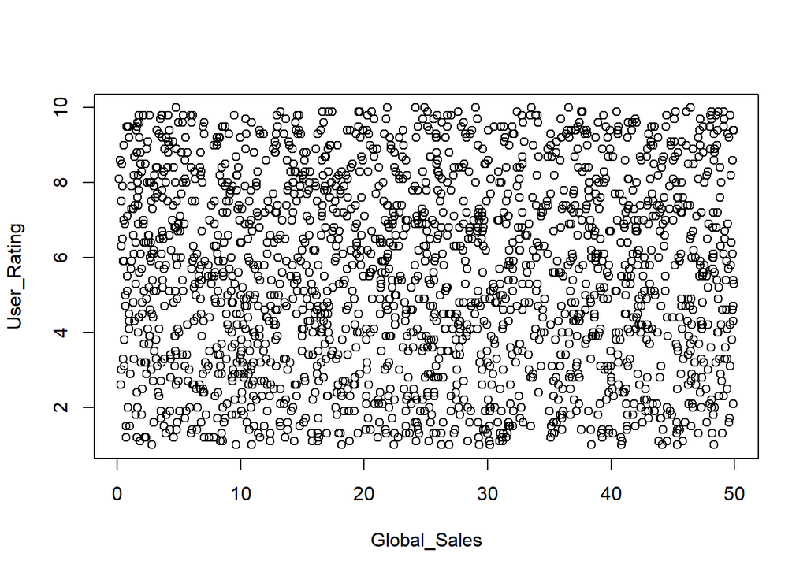

```r
res <- dbscan(df[,c("Global_Sales", "User_Rating")], eps = 3, minPts = 5)
plot(df[,c("Global_Sales", "User_Rating")], col = res$cluster)
points(df[res$cluster == 0,c("Global_Sales", "User_Rating")], pch = 3, col = "grey")
```

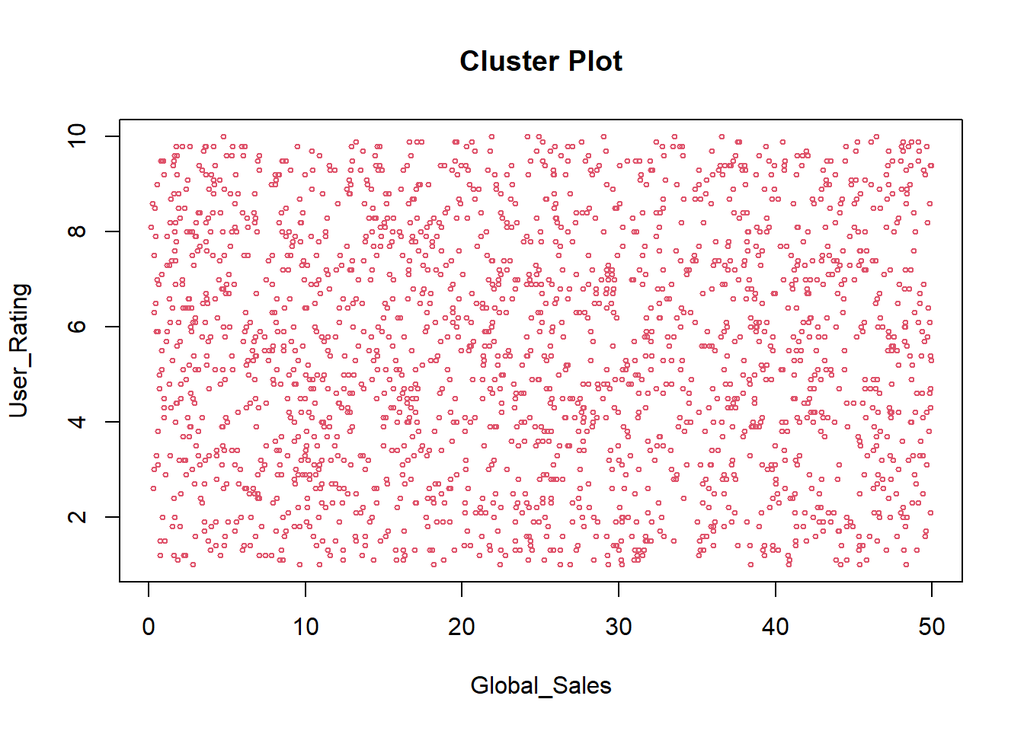

```r
clplot(df[,c("Global_Sales", "User_Rating")],res)
```

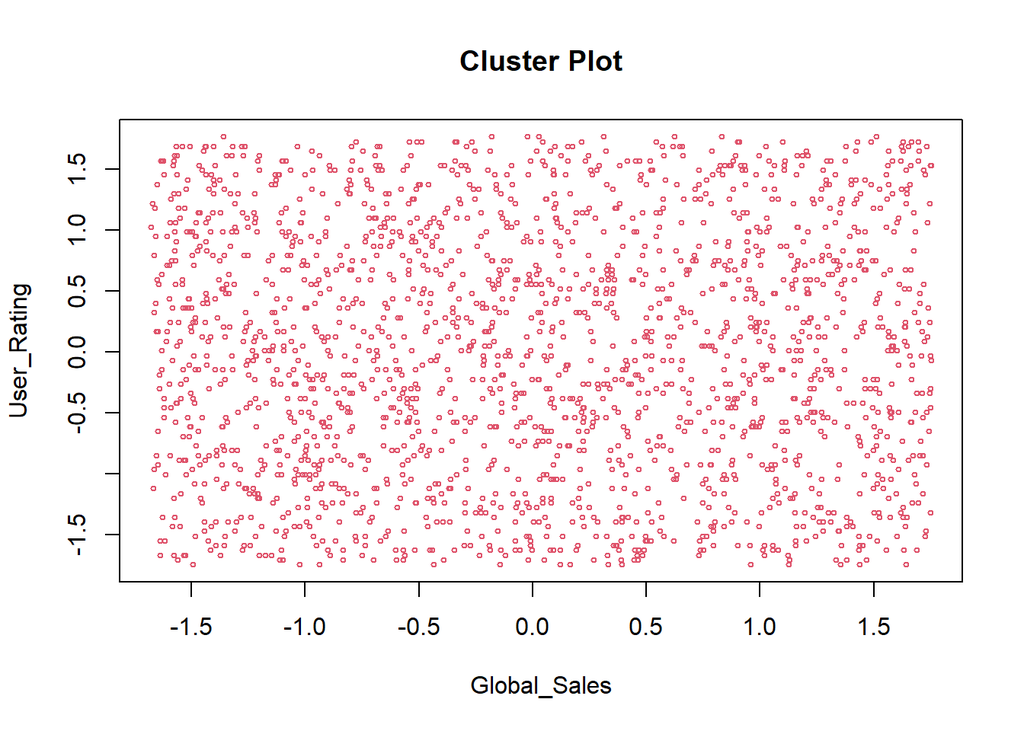

```r
x <- scale(df[,c("Global_Sales", "User_Rating")])

res <- dbscan(x, eps = 0.2)
clplot(x,res)
```

Above, I use the DBSCAN for my categorical variable. The main difference I can see is that the clustering has two different groups but the dbscan is all one group. There isn’t any outliers from clustering and the dbscan that I’ve seen. From the two different techniques I think it is not fair to compare them because the dbscan is looking for patterns and clustering is looking for which data is closer to each other.